# Multiple linear regression

```r
library(oilabs)
library(dplyr)
library(ggplot2)
data(evals)
```

| variable | description |
| --- | --- |
| `score` | average professor evaluation score: (1) very unsatisfactory - (5) excellent. |
| `rank` | rank of professor: teaching, tenure track, tenured. |
| `ethnicity` | ethnicity of professor: not minority, minority. |
| `gender` | gender of professor: female, male. |
| `language` | language of school where professor received education: English or non-English. |
| `age` | age of professor. |
| `cls_perc_eval` | percent of students in class who completed evaluation. |
| `cls_did_eval` | number of students in class who completed evaluation. |
| `cls_students` | total number of students in class. |
| `cls_level` | class level: lower, upper. |
| `cls_profs` | number of professors teaching sections in course in sample: single, multiple. |
| `cls_credits` | number of credits of class: one credit (lab, PE, etc.), multi credit. |
| `bty_f1lower` | beauty rating of professor from lower level female: (1) lowest - (10) highest. |
| `bty_f1upper` | beauty rating of professor from upper level female: (1) lowest - (10) highest. |
| `bty_f2upper` | beauty rating of professor from second upper level female: (1) lowest - (10) highest. |
| `bty_m1lower` | beauty rating of professor from lower level male: (1) lowest - (10) highest. |
| `bty_m1upper` | beauty rating of professor from upper level male: (1) lowest - (10) highest. |
| `bty_m2upper` | beauty rating of professor from second upper level male: (1) lowest - (10) highest. |
| `bty_avg` | average beauty rating of professor. |
| `pic_outfit` | outfit of professor in picture: not formal, formal. |
| `pic_color` | color of professor’s picture: color, black & white. |

1. Is this an observational study or an experiment? The original research question posed in the paper is whether beauty leads directly to the differences in course evaluations. Given the study design, is it possible to answer this question as it is phrased? If not, rephrase the question.

*This is an observational study making it difficult to make causal claims. The more appropriate research question would be whether there is an association between beauty and course evaluation score.*

2. Describe the distribution of `score`. Is the distribution skewed? What does that tell you about how students rate courses? Is this what you expected to see? Why, or why not?

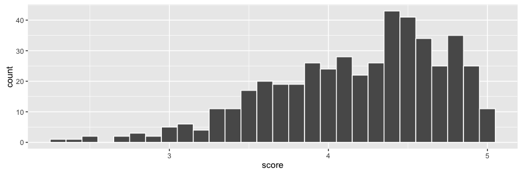

```r
qplot(x = score, data = evals, binwidth = 0.1, color = I("white"))
```

```r
summary(evals$score)
```

```
##    Min. 1st Qu.  Median    Mean 3rd Qu.    Max.
##   2.300   3.800   4.300   4.175   4.600   5.000
```

*The distribution of score takes a range between about 2.5 and 5, has a median score of 4.3 and an IQR of just less than 1. The shape is skewed to the left, which is what I expected. Students tend to be fairly generous, rating their professors either 4’s or 5’s, though occasionally there will be a professor that is quite unpopular. Even so, I am surprised at how high the minimum actually was: 2.3.*

3. Excluding `score`, select two other variables and describe their relationship using an appropriate visualization (scatterplot, side-by-side boxplots, or bar plots).

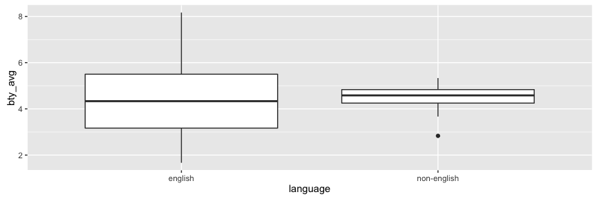

```r
qplot(x = language, y = bty_avg, data = evals, geom = "boxplot")
```

*Answers may vary. I chose to look first at the relationship between the native language of the professor and beauty average. The side-by-side boxplots show a lower median score for the English speakers. There are no outliers in the english group and one in the non-english. There is more spread for english than for non-english.

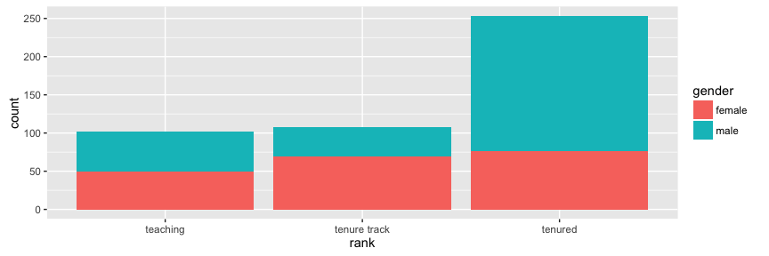

```r
qplot(x = rank, fill = gender, data = evals, geom = "bar")
```

*The second relationship that I investigated was between `gender` and `rank`. The stacked bar plot shows much higher representation of men at the tenured rank (around 70% of tenured faculty are men). The teaching faculty was an even split and the tenure track faculty show an over-representation of women (around two thirds).*

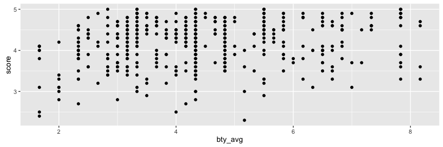

```r
qplot(x = bty_avg, y = score, data = evals, geom = "point")
```

4. Re-plot the scatterplot, but this time, jitter each of the points a bit by adding an additional layer to the plotting function: `+ geom_jitter()`. What was misleading about the initial scatterplot?

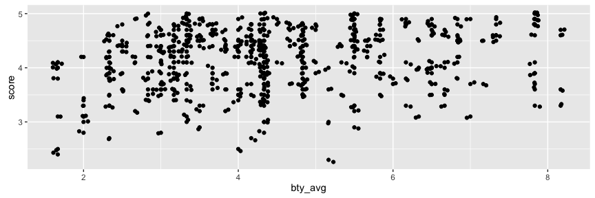

```r
qplot(x = bty_avg, y = score, data = evals, geom = "point") + geom_jitter()
```

*The initial scatterplot has lots of over-plotting - one dot representing many observations. Jittering fixes this by moving each of those stacks of dots just a bit so that they’re no longer on top of one another.*

5. Let’s see if the apparent trend in the plot is something more than natural variation. Fit a linear model called `m_bty` to predict average professor score by average beauty rating. Write out the equation for the linear model and interpret the slope. Is average beauty score a statistically significant predictor? Does it appear to be a practically significant predictor?

```r
m_bty <- lm(score ~ bty_avg, data = evals)
summary(m_bty)
```

```
##
## Call:
## lm(formula = score ~ bty_avg, data = evals)
##
## Residuals:
##     Min      1Q  Median      3Q     Max
## -1.9246 -0.3690  0.1420  0.3977  0.9309
##
## Coefficients:
##             Estimate Std. Error t value Pr(>|t|)
## (Intercept)  3.88034    0.07614   50.96  < 2e-16 ***
## bty_avg      0.06664    0.01629    4.09 5.08e-05 ***
## ---
## Signif. codes:  0 '***' 0.001 '**' 0.01 '*' 0.05 '.' 0.1 ' ' 1
##
## Residual standard error: 0.5348 on 461 degrees of freedom
## Multiple R-squared:  0.03502,    Adjusted R-squared:  0.03293
## F-statistic: 16.73 on 1 and 461 DF,  p-value: 5.083e-05
```

$$\hat{y} = 3.88 + 0.06 \times bty\_avg$$

It is a statistically significant predictor based on the small $p$-value. One would hope that beauty was not, in practice, a predictor of score though.

6. Use residual plots to evaluate whether the conditions of least squares regression are reasonable. Provide plots and comments for each one (see the Simple Regression Lab for a reminder of how to make these).

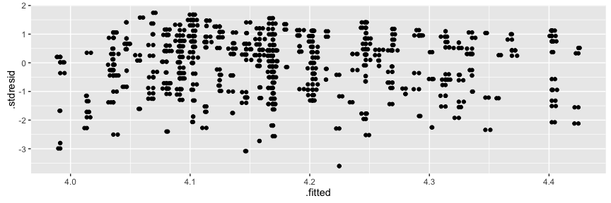

```r
qplot(x = .fitted, y = .stdresid, data = m_bty) + geom_jitter()
```

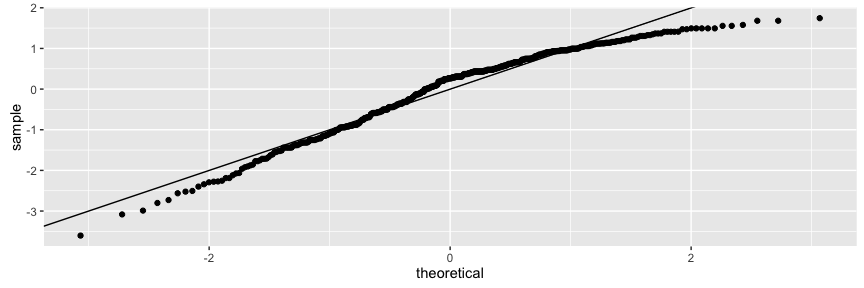

```r
qplot(sample = .stdresid, data = m_bty) + geom_abline()
```

*The linearity assumption seems reasonable given that our residual plot is fairly structure-less and the residuals are centered at zero across the range of fitted values. The constant variance assumption is also reasonable as the variance in the residuals looks to be constant across the range of fitted values. The more problematic assumption is that of normally distributed errors. The qq plot shows that we have a left skewed distribution (long left tail, short right tail). Finally, regarding the assumption of independent errors, there is no sign in the residuals of serial correlation. In terms of how the data was collected, if each row in our data set corresponds to a unique professor, it’s unlikely that there are over 4000 professors at this university, so we have reason to think that our sample constitutes more than 10% of the population and therefore that our errors may not be independent of one another.*

```r
m_bty_gen <- lm(score ~ bty_avg + gender, data = evals)
summary(m_bty_gen)
```

```
##
## Call:
## lm(formula = score ~ bty_avg + gender, data = evals)
##
## Residuals:
##     Min      1Q  Median      3Q     Max
## -1.8305 -0.3625  0.1055  0.4213  0.9314
##
## Coefficients:
##             Estimate Std. Error t value Pr(>|t|)
## (Intercept)  3.74734    0.08466  44.266  < 2e-16 ***
## bty_avg      0.07416    0.01625   4.563 6.48e-06 ***
## gendermale   0.17239    0.05022   3.433 0.000652 ***
## ---
## Signif. codes:  0 '***' 0.001 '**' 0.01 '*' 0.05 '.' 0.1 ' ' 1
##
## Residual standard error: 0.5287 on 460 degrees of freedom
## Multiple R-squared:  0.05912,    Adjusted R-squared:  0.05503
## F-statistic: 14.45 on 2 and 460 DF,  p-value: 8.177e-07
```

7. $P$-values and parameter estimates should only be trusted if the conditions for the regression are reasonable. Verify that the conditions for this model are reasonable using diagnostic plots.

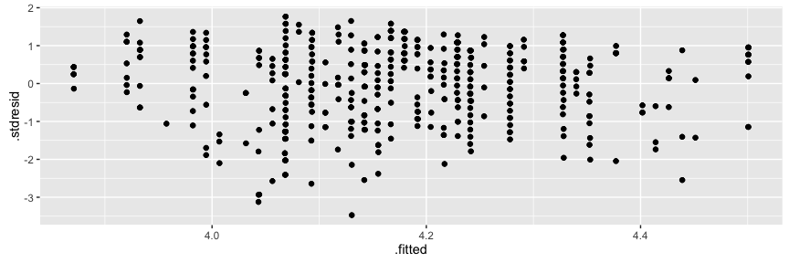

```r
qplot(x = .fitted, y = .stdresid, data = m_bty_gen) + geom_jitter()
```

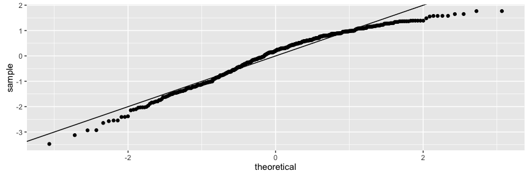

```r
qplot(sample = .stdresid, data = m_bty_gen) + geom_abline()
```

*The residual plot and the qq plot look very similar to that for the first model and thus the conclusions are the same: the normality assumption in the errors seems unrealistic and the independent errors assumption is questionable. Because of this, we expect that our $p$-values and parameter estimates may be off.*

8. Is `bty_avg` still a significant predictor of `score`? Has the addition of `gender` to the model changed the parameter estimate for `bty_avg`?

*Yes, `bty_avg` is still significant. The addition of `gender` has changed the estimate only slightly, from 0.066 to 0.074.*

9. What is the equation of the line corresponding to males? (*Hint:* For males, the parameter estimate is multiplied by 1.) For two professors who received the same beauty rating, which gender tends to have the higher course evaluation score?

$$\hat{y} = (3.75 + 0.1724) + 0.074 \times bty\_avg$$
$$\hat{y} = 3.92 + 0.074 \times bty\_avg$$

*For two professors of the same beauty rating, our model predicts that the male professor will have a score that is 0.1723 points higher.*

10. Create a new model called `m_bty_rank` with `gender` removed and `rank` added in. How does R appear to handle categorical variables that have more than two levels? Note that the rank variable has three levels: `teaching`, `tenure track`, `tenured`.

```r
m_bty_rank <- lm(score ~ bty_avg + rank, data = evals)
summary(m_bty_rank)
```

```
##
## Call:
## lm(formula = score ~ bty_avg + rank, data = evals)
##
## Residuals:
##     Min      1Q  Median      3Q     Max
## -1.8713 -0.3642  0.1489  0.4103  0.9525
##
## Coefficients:
##                  Estimate Std. Error t value Pr(>|t|)
## (Intercept)       3.98155    0.09078  43.860  < 2e-16 ***
## bty_avg           0.06783    0.01655   4.098 4.92e-05 ***
## ranktenure track -0.16070    0.07395  -2.173   0.0303 *
## ranktenured      -0.12623    0.06266  -2.014   0.0445 *
## ---
## Signif. codes:  0 '***' 0.001 '**' 0.01 '*' 0.05 '.' 0.1 ' ' 1
##
## Residual standard error: 0.5328 on 459 degrees of freedom
## Multiple R-squared:  0.04652,    Adjusted R-squared:  0.04029
## F-statistic: 7.465 on 3 and 459 DF,  p-value: 6.88e-05
```

*R has taken the `rank` variable and strung it out into 2 dummy variables to account for the three possible levels: tenure-track, tenured, and teaching.*

We will start with a full model that predicts professor score based on rank, ethnicity, gender, language of the university where they got their degree, age, proportion of students that filled out evaluations, class size, course level, number of professors, number of credits, average beauty rating, outfit, and picture color.

11. Which variable would you expect to have the highest $p$-value in this model? Why? *Hint:* Think about which variable would you expect to not have any association with the professor score.

*I’d expect `pic_color` to have the highest $p$-value in the model since it seems like it should be independent of score.*

Let’s run the model…

```r
m_full <- lm(score ~ rank + ethnicity + gender + language + age + cls_perc_eval
             + cls_students + cls_level + cls_profs + cls_credits + bty_avg
             + pic_outfit + pic_color, data = evals)
```

12. Check your suspicions from the previous exercise. Include the model output in your response.

```r
summary(m_full)
```

```
##
## Call:
## lm(formula = score ~ rank + ethnicity + gender + language + age +
##     cls_perc_eval + cls_students + cls_level + cls_profs + cls_credits +
##     bty_avg + pic_outfit + pic_color, data = evals)
##
## Residuals:
##      Min       1Q   Median       3Q      Max
## -1.77397 -0.32432  0.09067  0.35183  0.95036
##
## Coefficients:
##                         Estimate Std. Error t value Pr(>|t|)
## (Intercept)            4.0952141  0.2905277  14.096  < 2e-16 ***
## ranktenure track      -0.1475932  0.0820671  -1.798  0.07278 .
## ranktenured           -0.0973378  0.0663296  -1.467  0.14295
## ethnicitynot minority  0.1234929  0.0786273   1.571  0.11698
## gendermale             0.2109481  0.0518230   4.071 5.54e-05 ***
## languagenon-english   -0.2298112  0.1113754  -2.063  0.03965 *
## age                   -0.0090072  0.0031359  -2.872  0.00427 **
## cls_perc_eval          0.0053272  0.0015393   3.461  0.00059 ***
## cls_students           0.0004546  0.0003774   1.205  0.22896
## cls_levelupper         0.0605140  0.0575617   1.051  0.29369
## cls_profssingle       -0.0146619  0.0519885  -0.282  0.77806
## cls_creditsone credit  0.5020432  0.1159388   4.330 1.84e-05 ***
## bty_avg                0.0400333  0.0175064   2.287  0.02267 *
## pic_outfitnot formal  -0.1126817  0.0738800  -1.525  0.12792
## pic_colorcolor        -0.2172630  0.0715021  -3.039  0.00252 **
## ---
## Signif. codes:  0 '***' 0.001 '**' 0.01 '*' 0.05 '.' 0.1 ' ' 1
##
## Residual standard error: 0.498 on 448 degrees of freedom
## Multiple R-squared:  0.1871, Adjusted R-squared:  0.1617
## F-statistic: 7.366 on 14 and 448 DF,  p-value: 6.552e-14
```

13. Interpret the coefficient associated with the ethnicity variable.

*Holding all other variables in the model constant, we expect a professor that is considered “not minority” to have a score that is 0.123 points higher than a professor that is considered “minority”.*

14. Drop the variable with the highest $p$-value and re-fit the model. Did the coefficients and significance of the other explanatory variables change? (One of the things that makes multiple regression interesting is that coefficient estimates depend on the other variables that are included in the model.) If not, what does this say about whether or not the dropped variable was collinear with the other explanatory variables?

```r
m_full2 <- lm(score ~ rank + ethnicity + gender + language + age + cls_perc_eval +
                cls_students + cls_level + cls_credits + bty_avg + pic_outfit +
                pic_color, data = evals)
summary(m_full2)
```

```
##
## Call:
## lm(formula = score ~ rank + ethnicity + gender + language + age +
##     cls_perc_eval + cls_students + cls_level + cls_credits +
##     bty_avg + pic_outfit + pic_color, data = evals)
##
## Residuals:
##     Min      1Q  Median      3Q     Max
## -1.7836 -0.3257  0.0859  0.3513  0.9551
##
## Coefficients:
##                         Estimate Std. Error t value Pr(>|t|)
## (Intercept)            4.0872523  0.2888562  14.150  < 2e-16 ***
## ranktenure track      -0.1476746  0.0819824  -1.801 0.072327 .
## ranktenured           -0.0973829  0.0662614  -1.470 0.142349
## ethnicitynot minority  0.1274458  0.0772887   1.649 0.099856 .
## gendermale             0.2101231  0.0516873   4.065 5.66e-05 ***
## languagenon-english   -0.2282894  0.1111305  -2.054 0.040530 *
## age                   -0.0089992  0.0031326  -2.873 0.004262 **
## cls_perc_eval          0.0052888  0.0015317   3.453 0.000607 ***
## cls_students           0.0004687  0.0003737   1.254 0.210384
## cls_levelupper         0.0606374  0.0575010   1.055 0.292200
## cls_creditsone credit  0.5061196  0.1149163   4.404 1.33e-05 ***
## bty_avg                0.0398629  0.0174780   2.281 0.023032 *
## pic_outfitnot formal  -0.1083227  0.0721711  -1.501 0.134080
## pic_colorcolor        -0.2190527  0.0711469  -3.079 0.002205 **
## ---
## Signif. codes:  0 '***' 0.001 '**' 0.01 '*' 0.05 '.' 0.1 ' ' 1
##
## Residual standard error: 0.4974 on 449 degrees of freedom
## Multiple R-squared:  0.187,  Adjusted R-squared:  0.1634
## F-statistic: 7.943 on 13 and 449 DF,  p-value: 2.336e-14
```

*The coefficients and $p$-values have changed slightly, though the signs remain the same as in the full model. This suggests that the dropped variable had only minimal collinearity with the other explanatory variables.*

15. Using backward-selection and $p$-value as the selection criterion, determine the best model. (You may want to read over Subsection 6.2.2 of the text [here](https://drive.google.com/a/reed.edu/file/d/0B-DHaDEbiOGkRHNndUlBaHVmaGM/view) first if you haven’t already.) You do not need to show all steps in your answer, just the output for the final model. Also, write out the linear model for predicting score based on the final model you settle on.

```r
m_final <- lm(score ~ ethnicity + gender + language + age + cls_perc_eval +
                cls_credits + bty_avg + pic_color, data = evals)
summary(m_final)
```

```
##
## Call:
## lm(formula = score ~ ethnicity + gender + language + age + cls_perc_eval +
##     cls_credits + bty_avg + pic_color, data = evals)
##
## Residuals:
##      Min       1Q   Median       3Q      Max
## -1.85320 -0.32394  0.09984  0.37930  0.93610
##
## Coefficients:
##                        Estimate Std. Error t value Pr(>|t|)
## (Intercept)            3.771922   0.232053  16.255  < 2e-16 ***
## ethnicitynot minority  0.167872   0.075275   2.230  0.02623 *
## gendermale             0.207112   0.050135   4.131 4.30e-05 ***
## languagenon-english   -0.206178   0.103639  -1.989  0.04726 *
## age                   -0.006046   0.002612  -2.315  0.02108 *
## cls_perc_eval          0.004656   0.001435   3.244  0.00127 **
## cls_creditsone credit  0.505306   0.104119   4.853 1.67e-06 ***
## bty_avg                0.051069   0.016934   3.016  0.00271 **
## pic_colorcolor        -0.190579   0.067351  -2.830  0.00487 **
## ---
## Signif. codes:  0 '***' 0.001 '**' 0.01 '*' 0.05 '.' 0.1 ' ' 1
##
## Residual standard error: 0.4992 on 454 degrees of freedom
## Multiple R-squared:  0.1722, Adjusted R-squared:  0.1576
## F-statistic:  11.8 on 8 and 454 DF,  p-value: 2.58e-15
```

$$\hat{y} = 3.77 + 0.17 ethnicity\_not\_minority + 0.21 gendermale - 0.206 language\_non\_english \\
-0.006 age + 0.004 cls\_perc\_eval + 0.505 cls\_credits\_one\_credit + 0.05 bty\_avg \\
- 0.19 pic\_color\_color$$

16. Verify that the conditions for this model are reasonable using diagnostic plots.

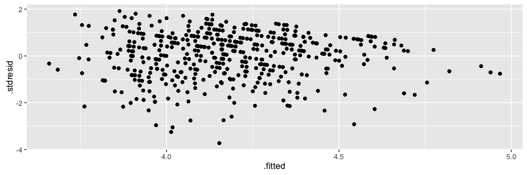

```r
qplot(x = .fitted, y = .stdresid, data = m_final) + geom_jitter()
```

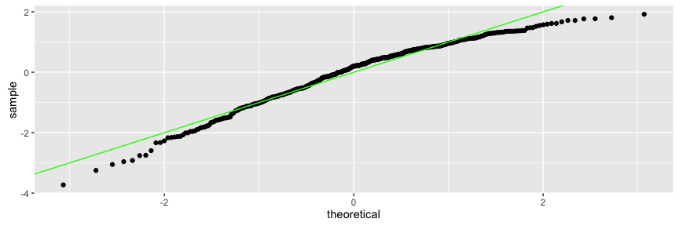

```r
qplot(sample = .stdresid, data = m_final) + geom_abline(col = "green")
```

*This model is violating assumptions left and right. The linear trend looks like the only sensible assumption give that the residuals are centered at zero across the range of the fitted values. The funnel-shaped pattern, however, indicates some decreasing variance. Additionally, our residuals are still left-skewed and we have the same reservations about independence.*

17. Based on your final model, describe the characteristics of a professor and course at University of Texas at Austin that would be associated with a high evaluation score.

*A high evaluation score would be associated with a professor who is male, not a minority, a native English speaker, young, rated to have high beauty using a black-and-white photo, has a high eval completion rate, and is teaching a one credit course.*

18. The original paper describes how these data were gathered by taking a sample of professors from the University of Texas at Austin and including all courses that they have taught. Considering that each row represents a course, could this new information have an impact on any of the conditions of linear regression?

*This makes the assumption of independent errors even less tenable as we’d expect that courses taught by the same professor will have similar scores.*

19. Would you be comfortable generalizing your conclusions to apply to professors generally (at any university)? Why or why not?

*We would be comfortable generalizing our conclusions to the broader population of all professors if our sample is representative of that population (that’s be once we have a valid model). There is good reason to think that the dynamics at play in a large research university like UT Austin will be quite different than those at a small liberals arts college like, say, Reed. Therefore we’d want to restrict our generalization to similar large universities.*

This is a product of OpenIntro that is released under a [Creative Commons Attribution-ShareAlike 3.0 Unported](http://creativecommons.org/licenses/by-sa/3.0). This lab was written by Mine Çetinkaya-Rundel, Andrew Bray, and Chester Ismay.